# Ch10_homework_2016-09-30

I think that I want to compare posterior distributions for the two types of models I’ll use the plotting function pairs to compare samples extracted from posterior

```r
# get map2stan up and ready
library(rstan)
rstan_options(auto_write = TRUE)
options(mc.cores = parallel::detectCores())

m10.H4.stan <- map2stan( m10.H4 , data=d , iter=1e4 , warmup=1000 )
```

[output not shown]

```
## Computing WAIC
```

```
## Constructing posterior predictions
```

```
## [ 900 / 9000 ]
[ 1800 / 9000 ]
[ 2700 / 9000 ]
[ 3600 / 9000 ]
[ 4500 / 9000 ]
[ 5400 / 9000 ]
[ 6300 / 9000 ]
[ 7200 / 9000 ]
[ 8100 / 9000 ]
[ 9000 / 9000 ]
```

```r
precis(m10.H4.stan) # looks fine
```

```
##     Mean StdDev lower 0.89 upper 0.89 n_eff Rhat
## a  -1.49   0.44      -2.19      -0.79  1475    1
## bc  0.03   0.01       0.02       0.04  1478    1
```

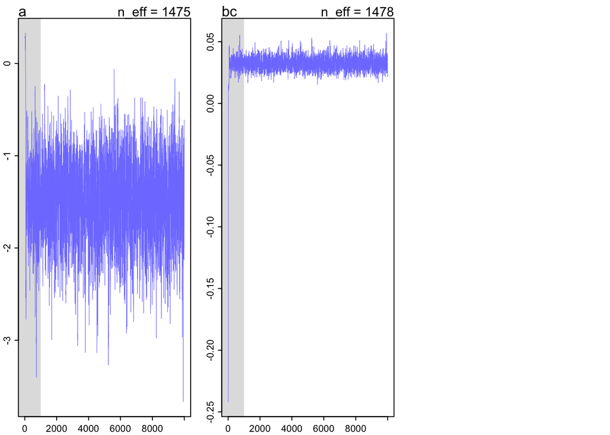

```r
plot(m10.H4.stan)

par( mfrow = c( 1,1 ) )
```

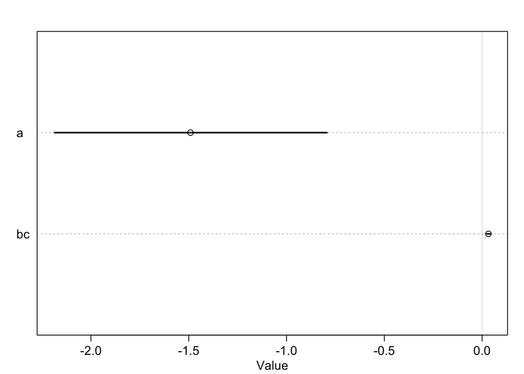

```r
plot(precis(m10.H4.stan)) # similar to MCMC
```

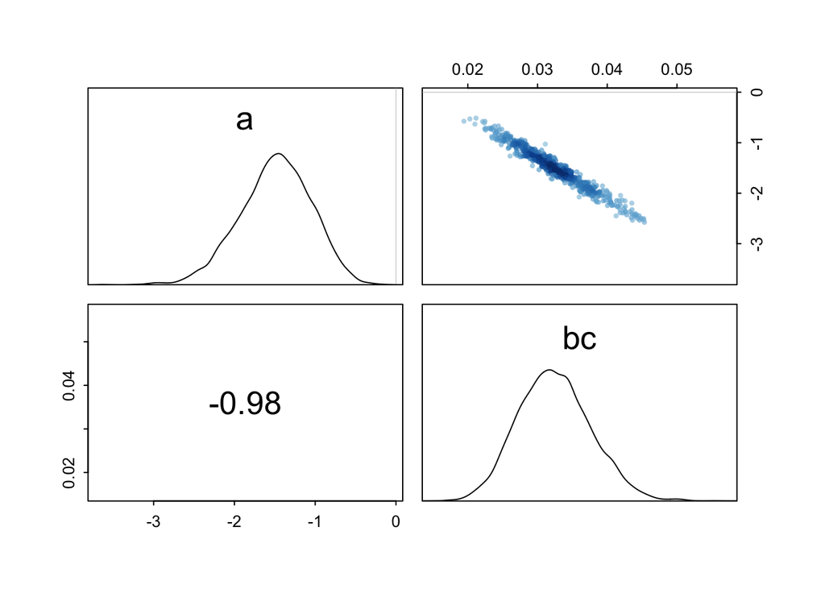

```r
pairs(m10.H4.stan) # ditto
```

Then plot the expected counts and their 89% interval against percent cover.

```r
# make plot of raw data to begin
plot(  d$PCTCOVER , d$SALAMAN ,col=rangi2 ,
      xlab="Salamanders" , ylab="Forest Cover" )
# only get high density of salamanders if high coverage

# sequence of forest coveragage to compute over
pred.df <- data.frame(PCTCOVER=seq(0,100,1))

# now I think I extract samples from posterior, then compute lambda
# link function should do this for me

lambda.pred.sal <- link(m10.H4, data = pred.df)
```

```
## [ 100 / 1000 ]
[ 200 / 1000 ]
[ 300 / 1000 ]
[ 400 / 1000 ]
[ 500 / 1000 ]
[ 600 / 1000 ]
[ 700 / 1000 ]
[ 800 / 1000 ]
[ 900 / 1000 ]
[ 1000 / 1000 ]
```

```r
lambda.median.sal <- apply( lambda.pred.sal , 2,median )
length(lambda.median.sal) # 101
```

```
## [1] 101
```

```r
lambda.PI.sal <- apply(lambda.pred.sal  , 2 , PI ) # default is 0.89
length(lambda.PI.sal) #202
```

```
## [1] 202
```

```r
# plot predicted trend for high contact islands
lines( pred.df$PCTCOVER , lambda.median.sal , col=rangi2 )
dim(pred.df) #101 by 1
```

```
## [1] 101   1
```

```r
length(lambda.median.sal) #101
```

```
## [1] 101
```

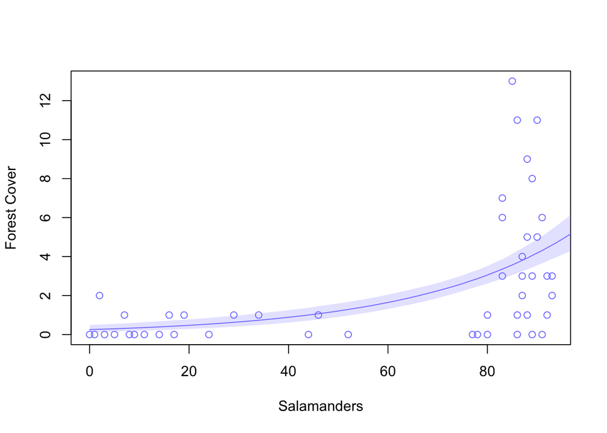

```r
shade( lambda.PI.sal , pred.df$PCTCOVER , col=col.alpha(rangi2,0.2) )
```

2. Can you improve the model by using the other predictor, FORESTAGE? Try any models you think useful. Can you explain why FORESTAGE helps or does not help with prediction?

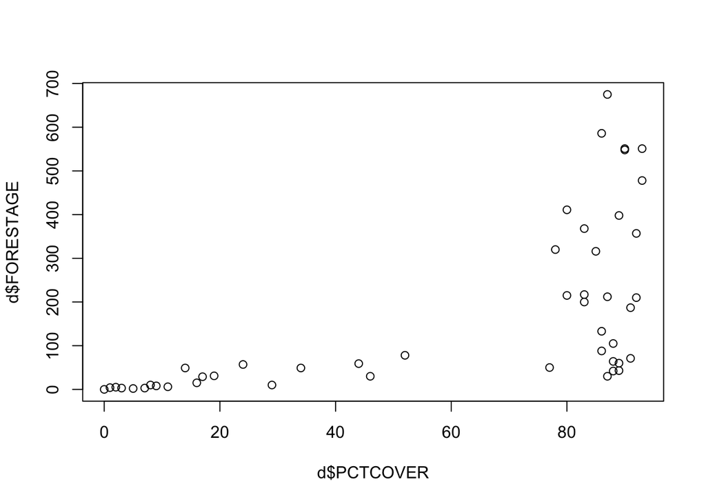

```r
plot(d$PCTCOVER, d$FORESTAGE)  # coverage is low for youngest stage; then at high coverage braod range of stages
```

```r
# Try simple model incorporating forest stage but no interaction term.
#And then a term with interaction between coverage and stage

#bc is for coverage; bs will be for stage

# incorporating forest stage and coverage; no interaction
m10.H6 <- map(
  alist(
    SALAMAN ~ dpois( lambda ),
    log(lambda) <- a + bc*PCTCOVER + bs*FORESTAGE,
    a ~ dnorm(0,2),
    c(bc,bs) ~ dnorm(0,1)
  ), data=d,
  method = "Nelder-Mead",
  start=list(a=0,bc=0,bs=0))
precis(m10.H6)
```

```
##     Mean StdDev  5.5% 94.5%
## a  -1.41   0.43 -2.11 -0.72
## bc  0.03   0.01  0.02  0.04
## bs  0.00   0.00  0.00  0.00
```

```r
# I am getting an error when I knit the above, althought it ran fine the first time
```

```r
# incorporating forest stage ; no coverage
m10.H8 <- map(
  alist(
    SALAMAN ~ dpois( lambda ),
    log(lambda) <- a + bs*FORESTAGE,
    a ~ dnorm(0,2),
    bs ~ dnorm(0,1)
  ), data=d )
# caution: model may not have converged
# failed once, worked the second time
```

```r
#ok, compare the 3 models
compare(m10.H4, m10.H6,m10.H8)
```

```
##         WAIC pWAIC dWAIC weight    SE   dSE
## m10.H4 213.5   4.8   0.0   0.83 26.20    NA
## m10.H6 216.6   6.9   3.1   0.17 26.64  0.86
## m10.H8 264.7   6.8  51.2   0.00 35.46 22.35
```

```r
# m10.H4 has most weight.
```

```r
#why does adding forest stage make model worse?
precis(m10.H4)
```

```
##     Mean StdDev  5.5% 94.5%
## a  -1.39   0.43 -2.08 -0.70
## bc  0.03   0.01  0.02  0.04
```

```r
precis(m10.H6) # bs (for forest stage) is 0.  contributes nothing to the model
```

```
##     Mean StdDev  5.5% 94.5%
## a  -1.41   0.43 -2.11 -0.72
## bc  0.03   0.01  0.02  0.04
## bs  0.00   0.00  0.00  0.00
```

```r
precis(m10.H8)  # this model didn't converge
```

```
##    Mean StdDev 5.5% 94.5%
## a   0.5   0.14 0.28  0.72
## bs  0.0   0.00 0.00  0.00
```

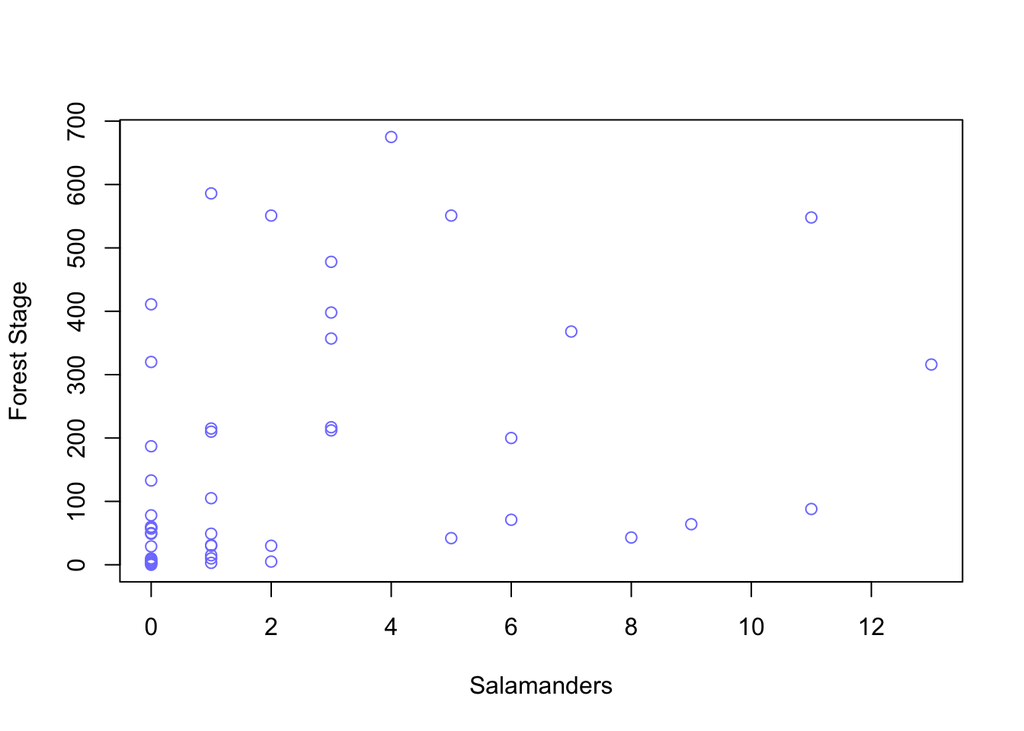

```r
# look at raw data
plot( d$SALAMAN , d$FORESTAGE , col=rangi2 ,
      xlab="Salamanders" , ylab="Forest Stage" )  # no obvious correlation
```